# College Majors

The significance of universities has been getting higher and higher since 21st century began. Many companies want to hire competitive college students to flourish, and it's believed that knowledge students can acquire in school year makes post-graduate life vividly colorful. However, some people started questioning about the quality of college education as its populality goes up. In my opinion as a current student, it's unarguable that some students are not motivated enough to study and end up with less satisfactory jobs.

In this notebook, I'm going to explore a dataset about college majors and their jobs after graduation (the data source link [here](https://github.com/fivethirtyeight/data/tree/master/college-majors)). Through data exploring, I'll find the answers of the following questions:

- Do students in more popular majors make more money?
- How many majors are predominantly male? Predominantly female?
- What majors have higher median salary and lower unemployment rate?

## Importing dataset

```python
import pandas as pd
import numpy as np
import matplotlib.mlab as mlab
import matplotlib.pyplot as plt
import statistics as stats
%matplotlib inline

recent_grad = pd.read_csv("recent-grads.csv", encoding="UTF-8")
recent_grad.info()
recent_grad.head()
```

```
<class 'pandas.core.frame.DataFrame'>
RangeIndex: 173 entries, 0 to 172
Data columns (total 21 columns):
Rank                    173 non-null int64
Major_code              173 non-null int64
Major                   173 non-null object
Total                   172 non-null float64
Men                     172 non-null float64
Women                   172 non-null float64
Major_category          173 non-null object
ShareWomen              172 non-null float64
Sample_size             173 non-null int64
Employed                173 non-null int64
Full_time               173 non-null int64
Part_time               173 non-null int64
Full_time_year_round    173 non-null int64
Unemployed              173 non-null int64
Unemployment_rate       173 non-null float64
Median                  173 non-null int64
P25th                   173 non-null int64
P75th                   173 non-null int64
College_jobs            173 non-null int64
Non_college_jobs        173 non-null int64
Low_wage_jobs           173 non-null int64
dtypes: float64(5), int64(14), object(2)
memory usage: 28.5+ KB
```

|  | Rank | Major_code | Major | Total | Men | Women | Major_category | ShareWomen | Sample_size | Employed | ... | Part_time | Full_time_year_round | Unemployed | Unemployment_rate | Median | P25th | P75th | College_jobs | Non_college_jobs | Low_wage_jobs |
| --- | --- | --- | --- | --- | --- | --- | --- | --- | --- | --- | --- | --- | --- | --- | --- | --- | --- | --- | --- | --- | --- |
| 0 | 1 | 2419 | PETROLEUM ENGINEERING | 2339.0 | 2057.0 | 282.0 | Engineering | 0.120564 | 36 | 1976 | ... | 270 | 1207 | 37 | 0.018381 | 110000 | 95000 | 125000 | 1534 | 364 | 193 |
| 1 | 2 | 2416 | MINING AND MINERAL ENGINEERING | 756.0 | 679.0 | 77.0 | Engineering | 0.101852 | 7 | 640 | ... | 170 | 388 | 85 | 0.117241 | 75000 | 55000 | 90000 | 350 | 257 | 50 |
| 2 | 3 | 2415 | METALLURGICAL ENGINEERING | 856.0 | 725.0 | 131.0 | Engineering | 0.153037 | 3 | 648 | ... | 133 | 340 | 16 | 0.024096 | 73000 | 50000 | 105000 | 456 | 176 | 0 |
| 3 | 4 | 2417 | NAVAL ARCHITECTURE AND MARINE ENGINEERING | 1258.0 | 1123.0 | 135.0 | Engineering | 0.107313 | 16 | 758 | ... | 150 | 692 | 40 | 0.050125 | 70000 | 43000 | 80000 | 529 | 102 | 0 |
| 4 | 5 | 2405 | CHEMICAL ENGINEERING | 32260.0 | 21239.0 | 11021.0 | Engineering | 0.341631 | 289 | 25694 | ... | 5180 | 16697 | 1672 | 0.061098 | 65000 | 50000 | 75000 | 18314 | 4440 | 972 |

5 rows × 21 columns

The information tells that we have 173 rows in total, but "`Total`", "`Men`", "`Women`", and "`ShareWomen`" columns have only 172 rows -- which means those columns have NaN values in it. Because NaN values makes some error occurs when we implement visualization, it's better to deal with rows containing NaN values.

```python
recent_grad.dropna(axis=0, inplace=True)
print(recent_grad.shape)
```

```
(172, 21)
```

## Popular Majors and Earnings

Firstly, we're going to explore dataset to find out a solution of questions which some students may want to know, that is, **"Do students in more popular majors make more money?"**. Because knowing how much they can potentially earn in the future can be a great motivation for students to learn in university, I think this analysis is worth implementing. Also, we're going to examine the relationship of gender difference and jobs.

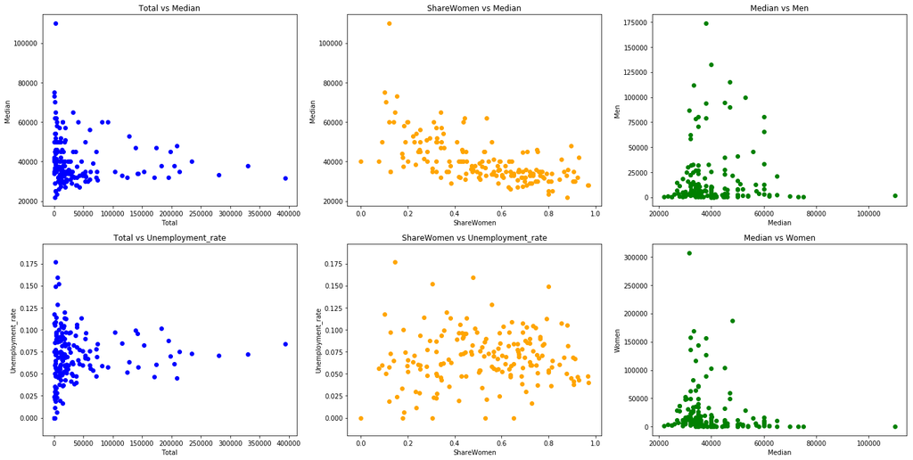

```python
axis = [["Total", "Median"],
        ["ShareWomen", "Median"],
        ["Median", "Men"],
        ["Total", "Unemployment_rate"],
        ["ShareWomen", "Unemployment_rate"],
        ["Median", "Women"]]
color = ["green", "blue", "orange"]

fig = plt.figure(figsize=(24, 12))
for i in range(len(axis)):
    ax = fig.add_subplot(2,(len(axis)/2),i+1)
    ax.scatter(recent_grad[axis[i][0]], recent_grad[axis[i][1]], c=color[((i+1)%3)])
    ax.set_xlabel(axis[i][0])
    ax.set_ylabel(axis[i][1])
    ax.set_title(axis[i][0] + " vs " + axis[i][1])
```

```python
correlation = recent_grad.corr()

print("Correlation of:")
for i in range(len(axis)):
    print(axis[i][0] + " and " + axis[i][1] + " is " + str(round(correlation[axis[i][0]][axis[i][1]], 3)))
```

```
Correlation of:
Total and Median is -0.107
ShareWomen and Median is -0.619
Median and Men is 0.026
Total and Unemployment_rate is 0.083
ShareWomen and Unemployment_rate is 0.073
Median and Women is -0.183
```

When it comes to unemployment rates, correlation of `0.083` say popularlity of majors makes no difference to it. This is very interesting result beacause that means students don't have to change their major to find a job technically (you may change your major if you want to earn more though).

Another thing we can say from the scatter plots and the correlations is that majors predominated by men generate higher salaries -- in other word, majors with more women have lower salaries unfortunately (correlation of `-0.619` shows strong negative relationship between ShareWomen and Median). Although men and women have equal rights to learn in colleges, it seems like we have another new issue to deal with.

The following grouped bar charts help us understand how much ShareWomen rate negatively relates to Median salaries.

[figure not shown]

```python
fig = plt.figure(figsize=(19, 6))
bar_position = np.arange(4)
bar_width = 0.35

# Median salary top 5 major
ax1 = fig.add_subplot(1,2,1)
p1 = ax1.bar(bar_position, recent_grad[:4]["Men"], bar_width)
p2 = ax1.bar((bar_position + bar_width), recent_grad[:4]["Women"], bar_width)

ax1.set_xticks(bar_position + (bar_width / 2))
ax1.set_xticklabels(labels=recent_grad[:4]["Major"], rotation=90)
ax1.set_ylabel("Frequency")
ax1.legend((p1,p2),('Men','Women'))
ax1.set_title('Men/Women - Top 5 Median Salary')

# Median salary bottom 5 major
ax2 = fig.add_subplot(1,2,2)
p3 = ax2.bar(bar_position, recent_grad[len(recent_grad)-4:]["Men"], bar_width)
p4 = ax2.bar((bar_position + bar_width), recent_grad[len(recent_grad)-4:]["Women"], bar_width)

ax2.set_xticks(bar_position + (bar_width / 2))
ax2.set_xticklabels(labels=recent_grad[len(recent_grad)-4:]["Major"], rotation=90)
ax2.set_ylabel("Frequency")
ax2.legend((p3,p4),('Men','Women'))
ax2.set_title('Men/Women  - Bottom 5 Median Salary')
```

## High Median Salary & Low Unemployment Rate Major Categories

In the previous section, we explored how popularity of majors is related to their future jobs. Now we will dive deeper into a question **"Which major category is best to earn money specifically?"** It totally depends on who you are what defines a good earning major, but I'd like to define it by "high median salary" and "low unemployment rate". And even though you don't really care about which major makes more money, it's worth knowing what the major is because those highly-demanding major may have significant influence on our life.

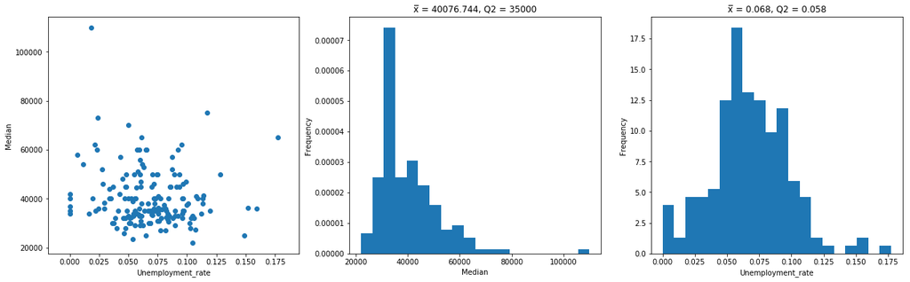

```python
fig = plt.figure(figsize=(21,6))
#Median vs Unemployment_rate Scatter
ax1 = fig.add_subplot(1,3,1)
ax1.scatter(recent_grad["Unemployment_rate"], recent_grad["Median"])
ax1.set_xlabel("Unemployment_rate")
ax1.set_ylabel("Median")

#Median Histogram
ax2 = fig.add_subplot(1,3,2)
ax2.hist(recent_grad["Median"], bins=20, density=1)
ax2.set_ylabel("Frequency")
ax2.set_xlabel("Median")
mean = np.mean(recent_grad["Median"])
mode = stats.mode(recent_grad["Median"])
ax2.set_title("x̅ = " + str(round(mean, 3)) + ", Q2 = " + str(mode))

#Unemployment_Rate Histogram
ax3 = fig.add_subplot(1,3,3)
ax3.hist(recent_grad["Unemployment_rate"], bins=20, density=1)
ax3.set_ylabel("Frequency")
ax3.set_xlabel("Unemployment_rate")
mean = np.mean(recent_grad["Unemployment_rate"])
mode = stats.mode(recent_grad["Unemployment_rate"])
ax3.set_title("x̅ = " + str(round(mean, 3)) + ", Q2 = " + str(0.058))
```

The histogram of median salary skews right, so that implies that we should choose the mode values for our analysis rather than the mean beacause the mean doesn't represent the entire Median data.  
On the other hand, the histogram of unemployment rate appear alomost the normal distribution. Thus, it's reasonable to use the mean value for our analysis.  
Now we're going to recreate scatter plots which reflect the condition that Median is highrer than its mode, and Unemployment rate is lower than its mean.

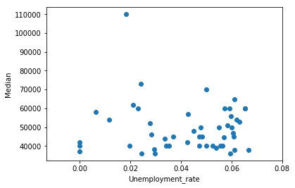

```
(49,)
```

|  | Major | Major_category | Median | Unemployment_rate |
| --- | --- | --- | --- | --- |
| 0 | PETROLEUM ENGINEERING | Engineering | 110000 | 0.018381 |
| 2 | METALLURGICAL ENGINEERING | Engineering | 73000 | 0.024096 |
| 3 | NAVAL ARCHITECTURE AND MARINE ENGINEERING | Engineering | 70000 | 0.050125 |
| 4 | CHEMICAL ENGINEERING | Engineering | 65000 | 0.061098 |
| 7 | ASTRONOMY AND ASTROPHYSICS | Physical Sciences | 62000 | 0.021167 |

```python
condition = (recent_grad["Median"] > 35000) & (recent_grad["Unemployment_rate"] < 0.068)
plt.scatter(recent_grad[condition]["Unemployment_rate"],
            recent_grad[condition]["Median"])
plt.xlabel("Unemployment_rate")
plt.ylabel("Median")
plt.show()

high_median_low_ur = recent_grad[condition]
h_m_l_ur = high_median_low_ur[["Major","Major_category","Median","Unemployment_rate"]]
print(high_median_low_ur["Major"].unique().shape)
h_m_l_ur.head()
```

The scatter plots appear that we still have many majors (of 49) and have much more room for improvement of data filtering. Now we're going to take the mean and the mode of `high_median_low_ur`, then find out better majors in terms of earning.

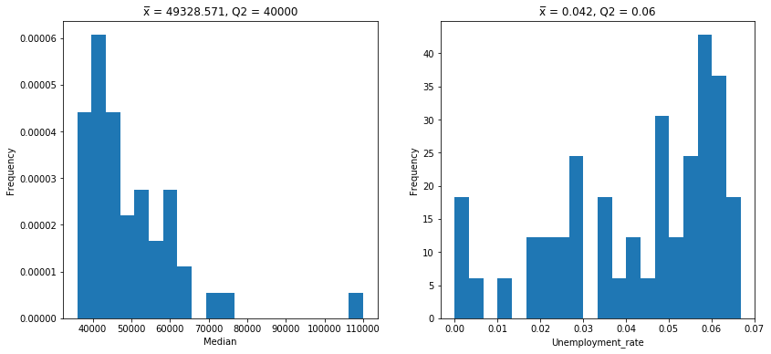

```python
fig = plt.figure(figsize=(21,6))

#Median Histogram
ax4 = fig.add_subplot(1,3,2)
ax4.hist(high_median_low_ur["Median"], bins=20, density=1)
ax4.set_ylabel("Frequency")
ax4.set_xlabel("Median")
mean = np.mean(high_median_low_ur["Median"])
mode = stats.mode(high_median_low_ur["Median"])
ax4.set_title("x̅ = " + str(round(mean, 3)) + ", Q2 = " + str(mode))

#Unemployment_Rate Histogram
ax5 = fig.add_subplot(1,3,3)
ax5.hist(high_median_low_ur["Unemployment_rate"], bins=20, density=1)
ax5.set_ylabel("Frequency")
ax5.set_xlabel("Unemployment_rate")
mean = np.mean(high_median_low_ur["Unemployment_rate"])
mode = stats.mode(high_median_low_ur["Unemployment_rate"])
ax5.set_title("x̅ = " + str(round(mean, 3)) + ", Q2 = " + str(0.06))
```

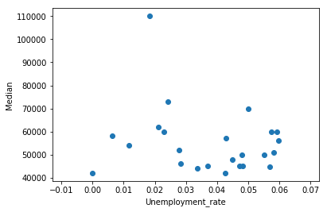

```
(24,)
Engineering                13
Health                      3
Physical Sciences           3
Business                    2
Computers & Mathematics     2
Law & Public Policy         1
Name: Major_category, dtype: int64
```

|  | Major | Major_category | Median | Unemployment_rate |
| --- | --- | --- | --- | --- |
| 0 | PETROLEUM ENGINEERING | Engineering | 110000 | 0.018381 |
| 2 | METALLURGICAL ENGINEERING | Engineering | 73000 | 0.024096 |
| 3 | NAVAL ARCHITECTURE AND MARINE ENGINEERING | Engineering | 70000 | 0.050125 |
| 7 | ASTRONOMY AND ASTROPHYSICS | Physical Sciences | 62000 | 0.021167 |
| 8 | MECHANICAL ENGINEERING | Engineering | 60000 | 0.057342 |
| 9 | ELECTRICAL ENGINEERING | Engineering | 60000 | 0.059174 |
| 13 | MATERIALS SCIENCE | Engineering | 60000 | 0.023043 |
| 14 | ENGINEERING MECHANICS PHYSICS AND SCIENCE | Engineering | 58000 | 0.006334 |
| 16 | INDUSTRIAL AND MANUFACTURING ENGINEERING | Engineering | 57000 | 0.042876 |
| 17 | GENERAL ENGINEERING | Engineering | 56000 | 0.059824 |
| 19 | COURT REPORTING | Law & Public Policy | 54000 | 0.011690 |
| 23 | MATERIALS ENGINEERING AND MATERIALS SCIENCE | Engineering | 52000 | 0.027789 |
| 24 | MANAGEMENT INFORMATION SYSTEMS AND STATISTICS | Business | 51000 | 0.058240 |
| 27 | OPERATIONS LOGISTICS AND E-COMMERCE | Business | 50000 | 0.047859 |
| 31 | ENGINEERING TECHNOLOGIES | Engineering | 50000 | 0.055030 |
| 34 | NURSING | Health | 48000 | 0.044863 |
| 38 | INDUSTRIAL PRODUCTION TECHNOLOGIES | Engineering | 46000 | 0.028308 |
| 41 | MATHEMATICS | Computers & Mathematics | 45000 | 0.047277 |
| 43 | PHYSICS | Physical Sciences | 45000 | 0.048224 |
| 44 | MEDICAL TECHNOLOGIES TECHNICIANS | Health | 45000 | 0.036983 |
| 49 | OCEANOGRAPHY | Physical Sciences | 44700 | 0.056995 |
| 50 | ENGINEERING AND INDUSTRIAL MANAGEMENT | Engineering | 44000 | 0.033652 |
| 51 | MEDICAL ASSISTING SERVICES | Health | 42000 | 0.042507 |
| 52 | MATHEMATICS AND COMPUTER SCIENCE | Computers & Mathematics | 42000 | 0.000000 |

```python
condition_ = (high_median_low_ur["Median"] > 40000) & (high_median_low_ur["Unemployment_rate"] < 0.06)
plt.scatter(high_median_low_ur[condition_]["Unemployment_rate"],
            high_median_low_ur[condition_]["Median"])
plt.xlabel("Unemployment_rate")
plt.ylabel("Median")
plt.show()

high_median_low_ur_ = high_median_low_ur[condition_]
h_m_l_ur_ = high_median_low_ur_[["Major","Major_category","Median","Unemployment_rate"]]
print(high_median_low_ur_["Major"].unique().shape)
print(high_median_low_ur_["Major_category"].value_counts())
h_m_l_ur_
```

### Conclusion

Now we've got decently small amount of data (24 out of 172 majors). It's interesting that more than half of the majors are categorized in Engineering, and more than 80% of the majors are scientific major ーEngineering, Health, Physical Science, and Computers & Mathematics.  
And the most promissing major in terms of earning is `PETROLEUM ENGINEERING`. So, for ones don't care about what they crave to learn but want to earn, or those who are not sure what they want to learn, Petroleum Engineering could be a potential choice to learn.

## Majors and Gender Relationship

```
164                              Education
163                                 Health
51                                  Health
138                              Education
150    Industrial Arts & Consumer Services
100                              Education
156               Psychology & Social Work
151               Psychology & Social Work
34                                  Health
88                                  Health
Name: Major_category, dtype: object
73     Industrial Arts & Consumer Services
66                             Engineering
26     Industrial Arts & Consumer Services
1                              Engineering
3                              Engineering
8                              Engineering
0                              Engineering
106    Industrial Arts & Consumer Services
111        Agriculture & Natural Resources
11                             Engineering
Name: Major_category, dtype: object
```

[figure not shown]

```python
high_sharewomen = recent_grad[recent_grad["ShareWomen"] > 0.5].sort_values(by="ShareWomen", ascending=False)
low_sharewomen = recent_grad[recent_grad["ShareWomen"] < 0.5].sort_values(by="ShareWomen", ascending=True)

fig = plt.figure(figsize=(18,6))
ax1 = fig.add_subplot(1,2,1)
ax2 = fig.add_subplot(1,2,2)
#the dataset is in descending order about "Median" column
high_sharewomen[:10].plot.bar(x="Major", y="ShareWomen", legend=False, ylim=(0.0, 1.0), ax=ax1)
low_sharewomen[:10].plot.bar(x="Major", y="ShareWomen", legend=False, ylim=(0.0, 1.0), ax=ax2)
ax1.set_title("Top 5 Majors predominated by WOMEN")
ax2.set_title("Top 5 Majors predominated by MEN")
ax1.set_ylabel("ShareWomen")
ax2.set_ylabel("ShareWomen")

print(high_sharewomen["Major_category"][:10])
print(low_sharewomen["Major_category"][:10])
```

```python
more_women_percentage = round(len(high_sharewomen)*100/len(recent_grad), 1)
more_men_percentage = round(len(low_sharewomen)*100/len(recent_grad), 1)
more_women = len(high_sharewomen)
more_men = len(low_sharewomen)

print(str(more_women_percentage) + "% of all majors have more women than men (" + str(more_women) + " majors)")
print(str(more_men_percentage) + "% of all majors have more men than women (" + str(more_men) + " majors)")
```

```
55.8% of all majors have more women than men (96 majors)
44.2% of all majors have more men than women (76 majors)
```

## Science Major and Women Rate

From now on we're going to use another dataset about college majors and genders. The dataset describes Men-Women ration in a specific year. The data source is [here](https://github.com/bokeh/bokeh/blob/master/bokeh/sampledata/_data/percent-bachelors-degrees-women-usa.csv)

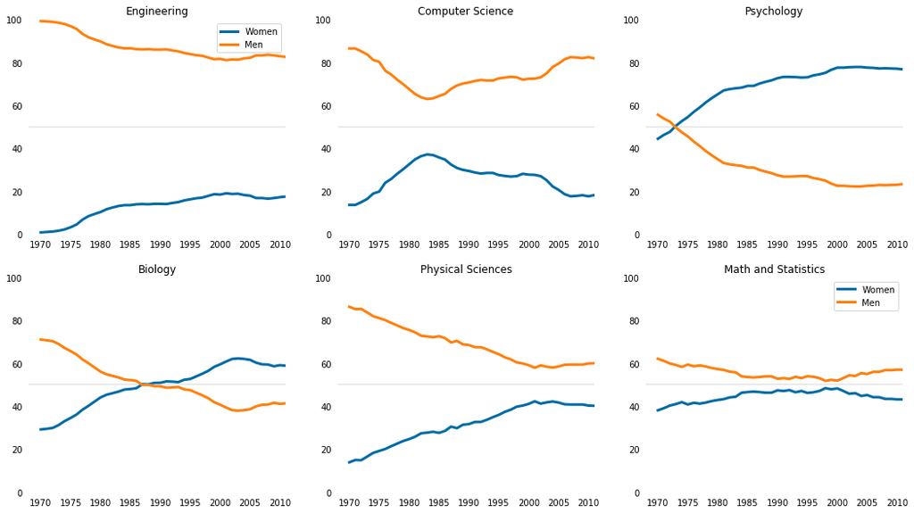

```python
women_degrees = pd.read_csv('percent-bachelors-degrees-women-usa.csv')
# the following colors are blind-friendly.
cb_dark_blue = (0/255,107/255,164/255)
cb_orange = (255/255, 128/255, 14/255)
stem_cats = ['Engineering', 'Computer Science', 'Psychology', 'Biology', 'Physical Sciences', 'Math and Statistics']

fig = plt.figure(figsize=(18, 10))

for i in range(0,6):
    ax = fig.add_subplot(2,3,i+1)
    ax.plot(women_degrees['Year'], women_degrees[stem_cats[i]], c=cb_dark_blue, label='Women', linewidth=3)
    ax.plot(women_degrees['Year'], 100-women_degrees[stem_cats[i]], c=cb_orange, label='Men', linewidth=3)
    for key,spine in ax.spines.items():
        spine.set_visible(False)
    ax.set_xlim(1968, 2011)
    ax.set_ylim(0,100)
    ax.set_title(stem_cats[i])
    ax.tick_params(bottom=False, top=False, left=False, right=False)
    ax.axhline(50, c=(171/255, 171/255, 171/255), alpha=0.3)

    if i == 0:
        ax.legend()
    elif i == 5:
        ax.legend()
plt.show()
```

## Liberal-Arts Major and Men

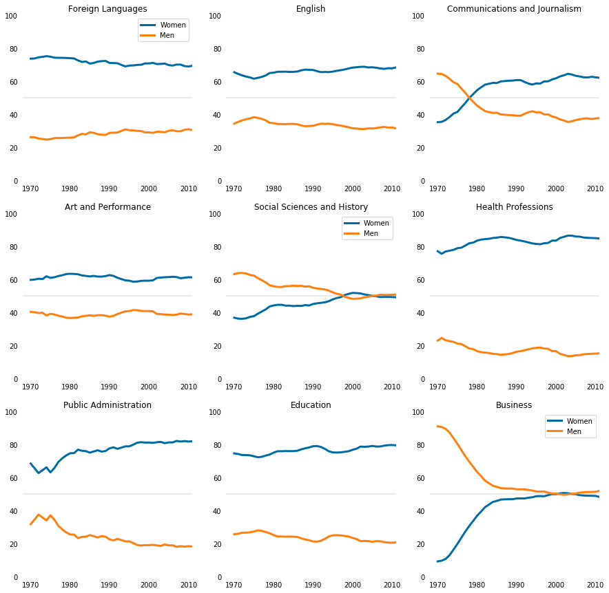

```python
lib_arts_cats = ['Foreign Languages',
                 'English',
                 'Communications and Journalism',
                 'Art and Performance',
                 'Social Sciences and History',
                 'Health Professions',
                 'Public Administration',
                 'Education',
                 'Business']

fig = plt.figure(figsize=(15, 15))

for i in range(0,9):
    ax = fig.add_subplot(3,3,i+1)
    ax.plot(women_degrees['Year'], women_degrees[lib_arts_cats[i]], c=cb_dark_blue, label='Women', linewidth=3)
    ax.plot(women_degrees['Year'], 100-women_degrees[lib_arts_cats[i]], c=cb_orange, label='Men', linewidth=3)
    for key,spine in ax.spines.items():
        spine.set_visible(False)
    ax.set_xlim(1968, 2011)
    ax.set_ylim(0,100)
    ax.set_title(lib_arts_cats[i])
    ax.tick_params(bottom=False, top=False, left=False, right=False)
    ax.axhline(50, c=(171/255, 171/255, 171/255), alpha=0.3)

    if i == 0:
        ax.legend()
    elif i == 4:
        ax.legend()
    elif i == 8:
        ax.legend()
plt.show()
```

### Conclusion

The 2 graphs above shows that men tend to predominate scientific majors and women do liberal-arts majors regardless of years (although we have some exceptions), and it's also obvious from the colored bar graph above. There are various possibilities which brought this consequence. One of them, which is most convincing to me, is that learning preference of men and women is largely different because of their brain mechanism or cultural roles in a society. There must be academic trend from year to year (Computer Science was temporally popular in 1985 for example). We can go deeper into this topic with sociology and neuroscience knowledge.